# Problems from the text book

## Chapter 2: Q8

a

```r
download.file("https://www.statlearning.com/s/College.csv", "College.csv")
```

```r
college <- read.csv("College.csv", stringsAsFactors = TRUE)
View(college)
```

A data.frame: 777 × 19

| X <fct> | Private <fct> | Apps <int> | Accept <int> | Enroll <int> | Top10perc <int> | Top25perc <int> | F.Undergrad <int> | P.Undergrad <int> | Outstate <int> | Room.Board <int> | Books <int> | Personal <int> | PhD <int> | Terminal <int> | S.F.Ratio <dbl> | perc.alumni <int> | Expend <int> | Grad.Rate <int> |
| --- | --- | --- | --- | --- | --- | --- | --- | --- | --- | --- | --- | --- | --- | --- | --- | --- | --- | --- |
| Abilene Christian University | Yes | 1660 | 1232 | 721 | 23 | 52 | 2885 | 537 | 7440 | 3300 | 450 | 2200 | 70 | 78 | 18.1 | 12 | 7041 | 60 |
| Adelphi University | Yes | 2186 | 1924 | 512 | 16 | 29 | 2683 | 1227 | 12280 | 6450 | 750 | 1500 | 29 | 30 | 12.2 | 16 | 10527 | 56 |
| Adrian College | Yes | 1428 | 1097 | 336 | 22 | 50 | 1036 | 99 | 11250 | 3750 | 400 | 1165 | 53 | 66 | 12.9 | 30 | 8735 | 54 |
| Agnes Scott College | Yes | 417 | 349 | 137 | 60 | 89 | 510 | 63 | 12960 | 5450 | 450 | 875 | 92 | 97 | 7.7 | 37 | 19016 | 59 |
| Alaska Pacific University | Yes | 193 | 146 | 55 | 16 | 44 | 249 | 869 | 7560 | 4120 | 800 | 1500 | 76 | 72 | 11.9 | 2 | 10922 | 15 |
| Albertson College | Yes | 587 | 479 | 158 | 38 | 62 | 678 | 41 | 13500 | 3335 | 500 | 675 | 67 | 73 | 9.4 | 11 | 9727 | 55 |
| Albertus Magnus College | Yes | 353 | 340 | 103 | 17 | 45 | 416 | 230 | 13290 | 5720 | 500 | 1500 | 90 | 93 | 11.5 | 26 | 8861 | 63 |
| Albion College | Yes | 1899 | 1720 | 489 | 37 | 68 | 1594 | 32 | 13868 | 4826 | 450 | 850 | 89 | 100 | 13.7 | 37 | 11487 | 73 |
| Albright College | Yes | 1038 | 839 | 227 | 30 | 63 | 973 | 306 | 15595 | 4400 | 300 | 500 | 79 | 84 | 11.3 | 23 | 11644 | 80 |
| Alderson-Broaddus College | Yes | 582 | 498 | 172 | 21 | 44 | 799 | 78 | 10468 | 3380 | 660 | 1800 | 40 | 41 | 11.5 | 15 | 8991 | 52 |
| Alfred University | Yes | 1732 | 1425 | 472 | 37 | 75 | 1830 | 110 | 16548 | 5406 | 500 | 600 | 82 | 88 | 11.3 | 31 | 10932 | 73 |
| Allegheny College | Yes | 2652 | 1900 | 484 | 44 | 77 | 1707 | 44 | 17080 | 4440 | 400 | 600 | 73 | 91 | 9.9 | 41 | 11711 | 76 |
| Allentown Coll. of St. Francis de Sales | Yes | 1179 | 780 | 290 | 38 | 64 | 1130 | 638 | 9690 | 4785 | 600 | 1000 | 60 | 84 | 13.3 | 21 | 7940 | 74 |
| Alma College | Yes | 1267 | 1080 | 385 | 44 | 73 | 1306 | 28 | 12572 | 4552 | 400 | 400 | 79 | 87 | 15.3 | 32 | 9305 | 68 |
| Alverno College | Yes | 494 | 313 | 157 | 23 | 46 | 1317 | 1235 | 8352 | 3640 | 650 | 2449 | 36 | 69 | 11.1 | 26 | 8127 | 55 |
| American International College | Yes | 1420 | 1093 | 220 | 9 | 22 | 1018 | 287 | 8700 | 4780 | 450 | 1400 | 78 | 84 | 14.7 | 19 | 7355 | 69 |
| Amherst College | Yes | 4302 | 992 | 418 | 83 | 96 | 1593 | 5 | 19760 | 5300 | 660 | 1598 | 93 | 98 | 8.4 | 63 | 21424 | 100 |
| Anderson University | Yes | 1216 | 908 | 423 | 19 | 40 | 1819 | 281 | 10100 | 3520 | 550 | 1100 | 48 | 61 | 12.1 | 14 | 7994 | 59 |
| Andrews University | Yes | 1130 | 704 | 322 | 14 | 23 | 1586 | 326 | 9996 | 3090 | 900 | 1320 | 62 | 66 | 11.5 | 18 | 10908 | 46 |
| Angelo State University | No | 3540 | 2001 | 1016 | 24 | 54 | 4190 | 1512 | 5130 | 3592 | 500 | 2000 | 60 | 62 | 23.1 | 5 | 4010 | 34 |
| Antioch University | Yes | 713 | 661 | 252 | 25 | 44 | 712 | 23 | 15476 | 3336 | 400 | 1100 | 69 | 82 | 11.3 | 35 | 42926 | 48 |
| Appalachian State University | No | 7313 | 4664 | 1910 | 20 | 63 | 9940 | 1035 | 6806 | 2540 | 96 | 2000 | 83 | 96 | 18.3 | 14 | 5854 | 70 |
| Aquinas College | Yes | 619 | 516 | 219 | 20 | 51 | 1251 | 767 | 11208 | 4124 | 350 | 1615 | 55 | 65 | 12.7 | 25 | 6584 | 65 |
| Arizona State University Main campus | No | 12809 | 10308 | 3761 | 24 | 49 | 22593 | 7585 | 7434 | 4850 | 700 | 2100 | 88 | 93 | 18.9 | 5 | 4602 | 48 |
| Arkansas College (Lyon College) | Yes | 708 | 334 | 166 | 46 | 74 | 530 | 182 | 8644 | 3922 | 500 | 800 | 79 | 88 | 12.6 | 24 | 14579 | 54 |
| Arkansas Tech University | No | 1734 | 1729 | 951 | 12 | 52 | 3602 | 939 | 3460 | 2650 | 450 | 1000 | 57 | 60 | 19.6 | 5 | 4739 | 48 |
| Assumption College | Yes | 2135 | 1700 | 491 | 23 | 59 | 1708 | 689 | 12000 | 5920 | 500 | 500 | 93 | 93 | 13.8 | 30 | 7100 | 88 |
| Auburn University-Main Campus | No | 7548 | 6791 | 3070 | 25 | 57 | 16262 | 1716 | 6300 | 3933 | 600 | 1908 | 85 | 91 | 16.7 | 18 | 6642 | 69 |
| Augsburg College | Yes | 662 | 513 | 257 | 12 | 30 | 2074 | 726 | 11902 | 4372 | 540 | 950 | 65 | 65 | 12.8 | 31 | 7836 | 58 |
| Augustana College IL | Yes | 1879 | 1658 | 497 | 36 | 69 | 1950 | 38 | 13353 | 4173 | 540 | 821 | 78 | 83 | 12.7 | 40 | 9220 | 71 |
| ⋮ | ⋮ | ⋮ | ⋮ | ⋮ | ⋮ | ⋮ | ⋮ | ⋮ | ⋮ | ⋮ | ⋮ | ⋮ | ⋮ | ⋮ | ⋮ | ⋮ | ⋮ | ⋮ |
| Westfield State College | No | 3100 | 2150 | 825 | 3 | 20 | 3234 | 941 | 5542 | 3788 | 500 | 1300 | 75 | 79 | 15.7 | 20 | 4222 | 65 |
| Westminster College MO | Yes | 662 | 553 | 184 | 20 | 43 | 665 | 37 | 10720 | 4050 | 600 | 1650 | 66 | 70 | 12.5 | 20 | 7925 | 62 |
| Westminster College | Yes | 996 | 866 | 377 | 29 | 58 | 1411 | 72 | 12065 | 3615 | 430 | 685 | 62 | 78 | 12.5 | 41 | 8596 | 80 |
| Westminster College of Salt Lake City | Yes | 917 | 720 | 213 | 21 | 60 | 979 | 743 | 8820 | 4050 | 600 | 2025 | 68 | 83 | 10.5 | 34 | 7170 | 50 |
| Westmont College | No | 950 | 713 | 351 | 42 | 72 | 1276 | 9 | 14320 | 5304 | 490 | 1410 | 77 | 77 | 14.9 | 17 | 8837 | 87 |
| Wheaton College IL | Yes | 1432 | 920 | 548 | 56 | 84 | 2200 | 56 | 11480 | 4200 | 530 | 1400 | 81 | 83 | 12.7 | 40 | 11916 | 85 |
| Westminster College PA | Yes | 1738 | 1373 | 417 | 21 | 55 | 1335 | 30 | 18460 | 5970 | 700 | 850 | 92 | 96 | 13.2 | 41 | 22704 | 71 |
| Wheeling Jesuit College | Yes | 903 | 755 | 213 | 15 | 49 | 971 | 305 | 10500 | 4545 | 600 | 600 | 66 | 71 | 14.1 | 27 | 7494 | 72 |
| Whitman College | Yes | 1861 | 998 | 359 | 45 | 77 | 1220 | 46 | 16670 | 4900 | 750 | 800 | 80 | 83 | 10.5 | 51 | 13198 | 72 |
| Whittier College | Yes | 1681 | 1069 | 344 | 35 | 63 | 1235 | 30 | 16249 | 5699 | 500 | 1998 | 84 | 92 | 13.6 | 29 | 11778 | 52 |
| Whitworth College | Yes | 1121 | 926 | 372 | 43 | 70 | 1270 | 160 | 12660 | 4500 | 678 | 2424 | 80 | 80 | 16.9 | 20 | 8328 | 80 |
| Widener University | Yes | 2139 | 1492 | 502 | 24 | 64 | 2186 | 2171 | 12350 | 5370 | 500 | 1350 | 88 | 86 | 12.6 | 19 | 9603 | 63 |
| Wilkes University | Yes | 1631 | 1431 | 434 | 15 | 36 | 1803 | 603 | 11150 | 5130 | 550 | 1260 | 78 | 92 | 13.3 | 24 | 8543 | 67 |
| Willamette University | Yes | 1658 | 1327 | 395 | 49 | 80 | 1595 | 159 | 14800 | 4620 | 400 | 790 | 91 | 94 | 13.3 | 37 | 10779 | 68 |
| William Jewell College | Yes | 663 | 547 | 315 | 32 | 67 | 1279 | 75 | 10060 | 2970 | 500 | 2600 | 74 | 80 | 11.2 | 19 | 7885 | 59 |
| William Woods University | Yes | 469 | 435 | 227 | 17 | 39 | 851 | 120 | 10535 | 4365 | 550 | 3700 | 39 | 66 | 12.9 | 16 | 7438 | 52 |
| Williams College | Yes | 4186 | 1245 | 526 | 81 | 96 | 1988 | 29 | 19629 | 5790 | 500 | 1200 | 94 | 99 | 9.0 | 64 | 22014 | 99 |
| Wilson College | Yes | 167 | 130 | 46 | 16 | 50 | 199 | 676 | 11428 | 5084 | 450 | 475 | 67 | 76 | 8.3 | 43 | 10291 | 67 |
| Wingate College | Yes | 1239 | 1017 | 383 | 10 | 34 | 1207 | 157 | 7820 | 3400 | 550 | 1550 | 69 | 81 | 13.9 | 8 | 7264 | 91 |
| Winona State University | No | 3325 | 2047 | 1301 | 20 | 45 | 5800 | 872 | 4200 | 2700 | 300 | 1200 | 53 | 60 | 20.2 | 18 | 5318 | 58 |
| Winthrop University | No | 2320 | 1805 | 769 | 24 | 61 | 3395 | 670 | 6400 | 3392 | 580 | 2150 | 71 | 80 | 12.8 | 26 | 6729 | 59 |
| Wisconsin Lutheran College | Yes | 152 | 128 | 75 | 17 | 41 | 282 | 22 | 9100 | 3700 | 500 | 1400 | 48 | 48 | 8.5 | 26 | 8960 | 50 |
| Wittenberg University | Yes | 1979 | 1739 | 575 | 42 | 68 | 1980 | 144 | 15948 | 4404 | 400 | 800 | 82 | 95 | 12.8 | 29 | 10414 | 78 |
| Wofford College | Yes | 1501 | 935 | 273 | 51 | 83 | 1059 | 34 | 12680 | 4150 | 605 | 1440 | 91 | 92 | 15.3 | 42 | 7875 | 75 |
| Worcester Polytechnic Institute | Yes | 2768 | 2314 | 682 | 49 | 86 | 2802 | 86 | 15884 | 5370 | 530 | 730 | 92 | 94 | 15.2 | 34 | 10774 | 82 |
| Worcester State College | No | 2197 | 1515 | 543 | 4 | 26 | 3089 | 2029 | 6797 | 3900 | 500 | 1200 | 60 | 60 | 21.0 | 14 | 4469 | 40 |
| Xavier University | Yes | 1959 | 1805 | 695 | 24 | 47 | 2849 | 1107 | 11520 | 4960 | 600 | 1250 | 73 | 75 | 13.3 | 31 | 9189 | 83 |
| Xavier University of Louisiana | Yes | 2097 | 1915 | 695 | 34 | 61 | 2793 | 166 | 6900 | 4200 | 617 | 781 | 67 | 75 | 14.4 | 20 | 8323 | 49 |
| Yale University | Yes | 10705 | 2453 | 1317 | 95 | 99 | 5217 | 83 | 19840 | 6510 | 630 | 2115 | 96 | 96 | 5.8 | 49 | 40386 | 99 |
| York College of Pennsylvania | Yes | 2989 | 1855 | 691 | 28 | 63 | 2988 | 1726 | 4990 | 3560 | 500 | 1250 | 75 | 75 | 18.1 | 28 | 4509 | 99 |

b

```r
rownames(college) <- college[, 1]
View(college)
```

A data.frame: 777 × 19

|  | X <fct> | Private <fct> | Apps <int> | Accept <int> | Enroll <int> | Top10perc <int> | Top25perc <int> | F.Undergrad <int> | P.Undergrad <int> | Outstate <int> | Room.Board <int> | Books <int> | Personal <int> | PhD <int> | Terminal <int> | S.F.Ratio <dbl> | perc.alumni <int> | Expend <int> | Grad.Rate <int> |
| --- | --- | --- | --- | --- | --- | --- | --- | --- | --- | --- | --- | --- | --- | --- | --- | --- | --- | --- | --- |
| Abilene Christian University | Abilene Christian University | Yes | 1660 | 1232 | 721 | 23 | 52 | 2885 | 537 | 7440 | 3300 | 450 | 2200 | 70 | 78 | 18.1 | 12 | 7041 | 60 |
| Adelphi University | Adelphi University | Yes | 2186 | 1924 | 512 | 16 | 29 | 2683 | 1227 | 12280 | 6450 | 750 | 1500 | 29 | 30 | 12.2 | 16 | 10527 | 56 |
| Adrian College | Adrian College | Yes | 1428 | 1097 | 336 | 22 | 50 | 1036 | 99 | 11250 | 3750 | 400 | 1165 | 53 | 66 | 12.9 | 30 | 8735 | 54 |
| Agnes Scott College | Agnes Scott College | Yes | 417 | 349 | 137 | 60 | 89 | 510 | 63 | 12960 | 5450 | 450 | 875 | 92 | 97 | 7.7 | 37 | 19016 | 59 |
| Alaska Pacific University | Alaska Pacific University | Yes | 193 | 146 | 55 | 16 | 44 | 249 | 869 | 7560 | 4120 | 800 | 1500 | 76 | 72 | 11.9 | 2 | 10922 | 15 |
| Albertson College | Albertson College | Yes | 587 | 479 | 158 | 38 | 62 | 678 | 41 | 13500 | 3335 | 500 | 675 | 67 | 73 | 9.4 | 11 | 9727 | 55 |
| Albertus Magnus College | Albertus Magnus College | Yes | 353 | 340 | 103 | 17 | 45 | 416 | 230 | 13290 | 5720 | 500 | 1500 | 90 | 93 | 11.5 | 26 | 8861 | 63 |
| Albion College | Albion College | Yes | 1899 | 1720 | 489 | 37 | 68 | 1594 | 32 | 13868 | 4826 | 450 | 850 | 89 | 100 | 13.7 | 37 | 11487 | 73 |
| Albright College | Albright College | Yes | 1038 | 839 | 227 | 30 | 63 | 973 | 306 | 15595 | 4400 | 300 | 500 | 79 | 84 | 11.3 | 23 | 11644 | 80 |
| Alderson-Broaddus College | Alderson-Broaddus College | Yes | 582 | 498 | 172 | 21 | 44 | 799 | 78 | 10468 | 3380 | 660 | 1800 | 40 | 41 | 11.5 | 15 | 8991 | 52 |
| Alfred University | Alfred University | Yes | 1732 | 1425 | 472 | 37 | 75 | 1830 | 110 | 16548 | 5406 | 500 | 600 | 82 | 88 | 11.3 | 31 | 10932 | 73 |
| Allegheny College | Allegheny College | Yes | 2652 | 1900 | 484 | 44 | 77 | 1707 | 44 | 17080 | 4440 | 400 | 600 | 73 | 91 | 9.9 | 41 | 11711 | 76 |
| Allentown Coll. of St. Francis de Sales | Allentown Coll. of St. Francis de Sales | Yes | 1179 | 780 | 290 | 38 | 64 | 1130 | 638 | 9690 | 4785 | 600 | 1000 | 60 | 84 | 13.3 | 21 | 7940 | 74 |
| Alma College | Alma College | Yes | 1267 | 1080 | 385 | 44 | 73 | 1306 | 28 | 12572 | 4552 | 400 | 400 | 79 | 87 | 15.3 | 32 | 9305 | 68 |
| Alverno College | Alverno College | Yes | 494 | 313 | 157 | 23 | 46 | 1317 | 1235 | 8352 | 3640 | 650 | 2449 | 36 | 69 | 11.1 | 26 | 8127 | 55 |
| American International College | American International College | Yes | 1420 | 1093 | 220 | 9 | 22 | 1018 | 287 | 8700 | 4780 | 450 | 1400 | 78 | 84 | 14.7 | 19 | 7355 | 69 |
| Amherst College | Amherst College | Yes | 4302 | 992 | 418 | 83 | 96 | 1593 | 5 | 19760 | 5300 | 660 | 1598 | 93 | 98 | 8.4 | 63 | 21424 | 100 |
| Anderson University | Anderson University | Yes | 1216 | 908 | 423 | 19 | 40 | 1819 | 281 | 10100 | 3520 | 550 | 1100 | 48 | 61 | 12.1 | 14 | 7994 | 59 |
| Andrews University | Andrews University | Yes | 1130 | 704 | 322 | 14 | 23 | 1586 | 326 | 9996 | 3090 | 900 | 1320 | 62 | 66 | 11.5 | 18 | 10908 | 46 |
| Angelo State University | Angelo State University | No | 3540 | 2001 | 1016 | 24 | 54 | 4190 | 1512 | 5130 | 3592 | 500 | 2000 | 60 | 62 | 23.1 | 5 | 4010 | 34 |
| Antioch University | Antioch University | Yes | 713 | 661 | 252 | 25 | 44 | 712 | 23 | 15476 | 3336 | 400 | 1100 | 69 | 82 | 11.3 | 35 | 42926 | 48 |
| Appalachian State University | Appalachian State University | No | 7313 | 4664 | 1910 | 20 | 63 | 9940 | 1035 | 6806 | 2540 | 96 | 2000 | 83 | 96 | 18.3 | 14 | 5854 | 70 |
| Aquinas College | Aquinas College | Yes | 619 | 516 | 219 | 20 | 51 | 1251 | 767 | 11208 | 4124 | 350 | 1615 | 55 | 65 | 12.7 | 25 | 6584 | 65 |
| Arizona State University Main campus | Arizona State University Main campus | No | 12809 | 10308 | 3761 | 24 | 49 | 22593 | 7585 | 7434 | 4850 | 700 | 2100 | 88 | 93 | 18.9 | 5 | 4602 | 48 |
| Arkansas College (Lyon College) | Arkansas College (Lyon College) | Yes | 708 | 334 | 166 | 46 | 74 | 530 | 182 | 8644 | 3922 | 500 | 800 | 79 | 88 | 12.6 | 24 | 14579 | 54 |
| Arkansas Tech University | Arkansas Tech University | No | 1734 | 1729 | 951 | 12 | 52 | 3602 | 939 | 3460 | 2650 | 450 | 1000 | 57 | 60 | 19.6 | 5 | 4739 | 48 |
| Assumption College | Assumption College | Yes | 2135 | 1700 | 491 | 23 | 59 | 1708 | 689 | 12000 | 5920 | 500 | 500 | 93 | 93 | 13.8 | 30 | 7100 | 88 |
| Auburn University-Main Campus | Auburn University-Main Campus | No | 7548 | 6791 | 3070 | 25 | 57 | 16262 | 1716 | 6300 | 3933 | 600 | 1908 | 85 | 91 | 16.7 | 18 | 6642 | 69 |
| Augsburg College | Augsburg College | Yes | 662 | 513 | 257 | 12 | 30 | 2074 | 726 | 11902 | 4372 | 540 | 950 | 65 | 65 | 12.8 | 31 | 7836 | 58 |
| Augustana College IL | Augustana College IL | Yes | 1879 | 1658 | 497 | 36 | 69 | 1950 | 38 | 13353 | 4173 | 540 | 821 | 78 | 83 | 12.7 | 40 | 9220 | 71 |
| ⋮ | ⋮ | ⋮ | ⋮ | ⋮ | ⋮ | ⋮ | ⋮ | ⋮ | ⋮ | ⋮ | ⋮ | ⋮ | ⋮ | ⋮ | ⋮ | ⋮ | ⋮ | ⋮ | ⋮ |
| Westfield State College | Westfield State College | No | 3100 | 2150 | 825 | 3 | 20 | 3234 | 941 | 5542 | 3788 | 500 | 1300 | 75 | 79 | 15.7 | 20 | 4222 | 65 |
| Westminster College MO | Westminster College MO | Yes | 662 | 553 | 184 | 20 | 43 | 665 | 37 | 10720 | 4050 | 600 | 1650 | 66 | 70 | 12.5 | 20 | 7925 | 62 |
| Westminster College | Westminster College | Yes | 996 | 866 | 377 | 29 | 58 | 1411 | 72 | 12065 | 3615 | 430 | 685 | 62 | 78 | 12.5 | 41 | 8596 | 80 |
| Westminster College of Salt Lake City | Westminster College of Salt Lake City | Yes | 917 | 720 | 213 | 21 | 60 | 979 | 743 | 8820 | 4050 | 600 | 2025 | 68 | 83 | 10.5 | 34 | 7170 | 50 |
| Westmont College | Westmont College | No | 950 | 713 | 351 | 42 | 72 | 1276 | 9 | 14320 | 5304 | 490 | 1410 | 77 | 77 | 14.9 | 17 | 8837 | 87 |
| Wheaton College IL | Wheaton College IL | Yes | 1432 | 920 | 548 | 56 | 84 | 2200 | 56 | 11480 | 4200 | 530 | 1400 | 81 | 83 | 12.7 | 40 | 11916 | 85 |
| Westminster College PA | Westminster College PA | Yes | 1738 | 1373 | 417 | 21 | 55 | 1335 | 30 | 18460 | 5970 | 700 | 850 | 92 | 96 | 13.2 | 41 | 22704 | 71 |
| Wheeling Jesuit College | Wheeling Jesuit College | Yes | 903 | 755 | 213 | 15 | 49 | 971 | 305 | 10500 | 4545 | 600 | 600 | 66 | 71 | 14.1 | 27 | 7494 | 72 |
| Whitman College | Whitman College | Yes | 1861 | 998 | 359 | 45 | 77 | 1220 | 46 | 16670 | 4900 | 750 | 800 | 80 | 83 | 10.5 | 51 | 13198 | 72 |
| Whittier College | Whittier College | Yes | 1681 | 1069 | 344 | 35 | 63 | 1235 | 30 | 16249 | 5699 | 500 | 1998 | 84 | 92 | 13.6 | 29 | 11778 | 52 |
| Whitworth College | Whitworth College | Yes | 1121 | 926 | 372 | 43 | 70 | 1270 | 160 | 12660 | 4500 | 678 | 2424 | 80 | 80 | 16.9 | 20 | 8328 | 80 |
| Widener University | Widener University | Yes | 2139 | 1492 | 502 | 24 | 64 | 2186 | 2171 | 12350 | 5370 | 500 | 1350 | 88 | 86 | 12.6 | 19 | 9603 | 63 |
| Wilkes University | Wilkes University | Yes | 1631 | 1431 | 434 | 15 | 36 | 1803 | 603 | 11150 | 5130 | 550 | 1260 | 78 | 92 | 13.3 | 24 | 8543 | 67 |
| Willamette University | Willamette University | Yes | 1658 | 1327 | 395 | 49 | 80 | 1595 | 159 | 14800 | 4620 | 400 | 790 | 91 | 94 | 13.3 | 37 | 10779 | 68 |
| William Jewell College | William Jewell College | Yes | 663 | 547 | 315 | 32 | 67 | 1279 | 75 | 10060 | 2970 | 500 | 2600 | 74 | 80 | 11.2 | 19 | 7885 | 59 |
| William Woods University | William Woods University | Yes | 469 | 435 | 227 | 17 | 39 | 851 | 120 | 10535 | 4365 | 550 | 3700 | 39 | 66 | 12.9 | 16 | 7438 | 52 |
| Williams College | Williams College | Yes | 4186 | 1245 | 526 | 81 | 96 | 1988 | 29 | 19629 | 5790 | 500 | 1200 | 94 | 99 | 9.0 | 64 | 22014 | 99 |
| Wilson College | Wilson College | Yes | 167 | 130 | 46 | 16 | 50 | 199 | 676 | 11428 | 5084 | 450 | 475 | 67 | 76 | 8.3 | 43 | 10291 | 67 |
| Wingate College | Wingate College | Yes | 1239 | 1017 | 383 | 10 | 34 | 1207 | 157 | 7820 | 3400 | 550 | 1550 | 69 | 81 | 13.9 | 8 | 7264 | 91 |
| Winona State University | Winona State University | No | 3325 | 2047 | 1301 | 20 | 45 | 5800 | 872 | 4200 | 2700 | 300 | 1200 | 53 | 60 | 20.2 | 18 | 5318 | 58 |
| Winthrop University | Winthrop University | No | 2320 | 1805 | 769 | 24 | 61 | 3395 | 670 | 6400 | 3392 | 580 | 2150 | 71 | 80 | 12.8 | 26 | 6729 | 59 |
| Wisconsin Lutheran College | Wisconsin Lutheran College | Yes | 152 | 128 | 75 | 17 | 41 | 282 | 22 | 9100 | 3700 | 500 | 1400 | 48 | 48 | 8.5 | 26 | 8960 | 50 |
| Wittenberg University | Wittenberg University | Yes | 1979 | 1739 | 575 | 42 | 68 | 1980 | 144 | 15948 | 4404 | 400 | 800 | 82 | 95 | 12.8 | 29 | 10414 | 78 |
| Wofford College | Wofford College | Yes | 1501 | 935 | 273 | 51 | 83 | 1059 | 34 | 12680 | 4150 | 605 | 1440 | 91 | 92 | 15.3 | 42 | 7875 | 75 |
| Worcester Polytechnic Institute | Worcester Polytechnic Institute | Yes | 2768 | 2314 | 682 | 49 | 86 | 2802 | 86 | 15884 | 5370 | 530 | 730 | 92 | 94 | 15.2 | 34 | 10774 | 82 |
| Worcester State College | Worcester State College | No | 2197 | 1515 | 543 | 4 | 26 | 3089 | 2029 | 6797 | 3900 | 500 | 1200 | 60 | 60 | 21.0 | 14 | 4469 | 40 |
| Xavier University | Xavier University | Yes | 1959 | 1805 | 695 | 24 | 47 | 2849 | 1107 | 11520 | 4960 | 600 | 1250 | 73 | 75 | 13.3 | 31 | 9189 | 83 |
| Xavier University of Louisiana | Xavier University of Louisiana | Yes | 2097 | 1915 | 695 | 34 | 61 | 2793 | 166 | 6900 | 4200 | 617 | 781 | 67 | 75 | 14.4 | 20 | 8323 | 49 |
| Yale University | Yale University | Yes | 10705 | 2453 | 1317 | 95 | 99 | 5217 | 83 | 19840 | 6510 | 630 | 2115 | 96 | 96 | 5.8 | 49 | 40386 | 99 |
| York College of Pennsylvania | York College of Pennsylvania | Yes | 2989 | 1855 | 691 | 28 | 63 | 2988 | 1726 | 4990 | 3560 | 500 | 1250 | 75 | 75 | 18.1 | 28 | 4509 | 99 |

```r
college <- college[, -1]
View(college)
```

A data.frame: 777 × 18

|  | Private <fct> | Apps <int> | Accept <int> | Enroll <int> | Top10perc <int> | Top25perc <int> | F.Undergrad <int> | P.Undergrad <int> | Outstate <int> | Room.Board <int> | Books <int> | Personal <int> | PhD <int> | Terminal <int> | S.F.Ratio <dbl> | perc.alumni <int> | Expend <int> | Grad.Rate <int> |
| --- | --- | --- | --- | --- | --- | --- | --- | --- | --- | --- | --- | --- | --- | --- | --- | --- | --- | --- |
| Abilene Christian University | Yes | 1660 | 1232 | 721 | 23 | 52 | 2885 | 537 | 7440 | 3300 | 450 | 2200 | 70 | 78 | 18.1 | 12 | 7041 | 60 |
| Adelphi University | Yes | 2186 | 1924 | 512 | 16 | 29 | 2683 | 1227 | 12280 | 6450 | 750 | 1500 | 29 | 30 | 12.2 | 16 | 10527 | 56 |
| Adrian College | Yes | 1428 | 1097 | 336 | 22 | 50 | 1036 | 99 | 11250 | 3750 | 400 | 1165 | 53 | 66 | 12.9 | 30 | 8735 | 54 |
| Agnes Scott College | Yes | 417 | 349 | 137 | 60 | 89 | 510 | 63 | 12960 | 5450 | 450 | 875 | 92 | 97 | 7.7 | 37 | 19016 | 59 |
| Alaska Pacific University | Yes | 193 | 146 | 55 | 16 | 44 | 249 | 869 | 7560 | 4120 | 800 | 1500 | 76 | 72 | 11.9 | 2 | 10922 | 15 |
| Albertson College | Yes | 587 | 479 | 158 | 38 | 62 | 678 | 41 | 13500 | 3335 | 500 | 675 | 67 | 73 | 9.4 | 11 | 9727 | 55 |
| Albertus Magnus College | Yes | 353 | 340 | 103 | 17 | 45 | 416 | 230 | 13290 | 5720 | 500 | 1500 | 90 | 93 | 11.5 | 26 | 8861 | 63 |
| Albion College | Yes | 1899 | 1720 | 489 | 37 | 68 | 1594 | 32 | 13868 | 4826 | 450 | 850 | 89 | 100 | 13.7 | 37 | 11487 | 73 |
| Albright College | Yes | 1038 | 839 | 227 | 30 | 63 | 973 | 306 | 15595 | 4400 | 300 | 500 | 79 | 84 | 11.3 | 23 | 11644 | 80 |
| Alderson-Broaddus College | Yes | 582 | 498 | 172 | 21 | 44 | 799 | 78 | 10468 | 3380 | 660 | 1800 | 40 | 41 | 11.5 | 15 | 8991 | 52 |
| Alfred University | Yes | 1732 | 1425 | 472 | 37 | 75 | 1830 | 110 | 16548 | 5406 | 500 | 600 | 82 | 88 | 11.3 | 31 | 10932 | 73 |
| Allegheny College | Yes | 2652 | 1900 | 484 | 44 | 77 | 1707 | 44 | 17080 | 4440 | 400 | 600 | 73 | 91 | 9.9 | 41 | 11711 | 76 |
| Allentown Coll. of St. Francis de Sales | Yes | 1179 | 780 | 290 | 38 | 64 | 1130 | 638 | 9690 | 4785 | 600 | 1000 | 60 | 84 | 13.3 | 21 | 7940 | 74 |
| Alma College | Yes | 1267 | 1080 | 385 | 44 | 73 | 1306 | 28 | 12572 | 4552 | 400 | 400 | 79 | 87 | 15.3 | 32 | 9305 | 68 |
| Alverno College | Yes | 494 | 313 | 157 | 23 | 46 | 1317 | 1235 | 8352 | 3640 | 650 | 2449 | 36 | 69 | 11.1 | 26 | 8127 | 55 |
| American International College | Yes | 1420 | 1093 | 220 | 9 | 22 | 1018 | 287 | 8700 | 4780 | 450 | 1400 | 78 | 84 | 14.7 | 19 | 7355 | 69 |
| Amherst College | Yes | 4302 | 992 | 418 | 83 | 96 | 1593 | 5 | 19760 | 5300 | 660 | 1598 | 93 | 98 | 8.4 | 63 | 21424 | 100 |
| Anderson University | Yes | 1216 | 908 | 423 | 19 | 40 | 1819 | 281 | 10100 | 3520 | 550 | 1100 | 48 | 61 | 12.1 | 14 | 7994 | 59 |
| Andrews University | Yes | 1130 | 704 | 322 | 14 | 23 | 1586 | 326 | 9996 | 3090 | 900 | 1320 | 62 | 66 | 11.5 | 18 | 10908 | 46 |
| Angelo State University | No | 3540 | 2001 | 1016 | 24 | 54 | 4190 | 1512 | 5130 | 3592 | 500 | 2000 | 60 | 62 | 23.1 | 5 | 4010 | 34 |
| Antioch University | Yes | 713 | 661 | 252 | 25 | 44 | 712 | 23 | 15476 | 3336 | 400 | 1100 | 69 | 82 | 11.3 | 35 | 42926 | 48 |
| Appalachian State University | No | 7313 | 4664 | 1910 | 20 | 63 | 9940 | 1035 | 6806 | 2540 | 96 | 2000 | 83 | 96 | 18.3 | 14 | 5854 | 70 |
| Aquinas College | Yes | 619 | 516 | 219 | 20 | 51 | 1251 | 767 | 11208 | 4124 | 350 | 1615 | 55 | 65 | 12.7 | 25 | 6584 | 65 |
| Arizona State University Main campus | No | 12809 | 10308 | 3761 | 24 | 49 | 22593 | 7585 | 7434 | 4850 | 700 | 2100 | 88 | 93 | 18.9 | 5 | 4602 | 48 |
| Arkansas College (Lyon College) | Yes | 708 | 334 | 166 | 46 | 74 | 530 | 182 | 8644 | 3922 | 500 | 800 | 79 | 88 | 12.6 | 24 | 14579 | 54 |
| Arkansas Tech University | No | 1734 | 1729 | 951 | 12 | 52 | 3602 | 939 | 3460 | 2650 | 450 | 1000 | 57 | 60 | 19.6 | 5 | 4739 | 48 |
| Assumption College | Yes | 2135 | 1700 | 491 | 23 | 59 | 1708 | 689 | 12000 | 5920 | 500 | 500 | 93 | 93 | 13.8 | 30 | 7100 | 88 |
| Auburn University-Main Campus | No | 7548 | 6791 | 3070 | 25 | 57 | 16262 | 1716 | 6300 | 3933 | 600 | 1908 | 85 | 91 | 16.7 | 18 | 6642 | 69 |
| Augsburg College | Yes | 662 | 513 | 257 | 12 | 30 | 2074 | 726 | 11902 | 4372 | 540 | 950 | 65 | 65 | 12.8 | 31 | 7836 | 58 |
| Augustana College IL | Yes | 1879 | 1658 | 497 | 36 | 69 | 1950 | 38 | 13353 | 4173 | 540 | 821 | 78 | 83 | 12.7 | 40 | 9220 | 71 |
| ⋮ | ⋮ | ⋮ | ⋮ | ⋮ | ⋮ | ⋮ | ⋮ | ⋮ | ⋮ | ⋮ | ⋮ | ⋮ | ⋮ | ⋮ | ⋮ | ⋮ | ⋮ | ⋮ |
| Westfield State College | No | 3100 | 2150 | 825 | 3 | 20 | 3234 | 941 | 5542 | 3788 | 500 | 1300 | 75 | 79 | 15.7 | 20 | 4222 | 65 |
| Westminster College MO | Yes | 662 | 553 | 184 | 20 | 43 | 665 | 37 | 10720 | 4050 | 600 | 1650 | 66 | 70 | 12.5 | 20 | 7925 | 62 |
| Westminster College | Yes | 996 | 866 | 377 | 29 | 58 | 1411 | 72 | 12065 | 3615 | 430 | 685 | 62 | 78 | 12.5 | 41 | 8596 | 80 |
| Westminster College of Salt Lake City | Yes | 917 | 720 | 213 | 21 | 60 | 979 | 743 | 8820 | 4050 | 600 | 2025 | 68 | 83 | 10.5 | 34 | 7170 | 50 |
| Westmont College | No | 950 | 713 | 351 | 42 | 72 | 1276 | 9 | 14320 | 5304 | 490 | 1410 | 77 | 77 | 14.9 | 17 | 8837 | 87 |
| Wheaton College IL | Yes | 1432 | 920 | 548 | 56 | 84 | 2200 | 56 | 11480 | 4200 | 530 | 1400 | 81 | 83 | 12.7 | 40 | 11916 | 85 |
| Westminster College PA | Yes | 1738 | 1373 | 417 | 21 | 55 | 1335 | 30 | 18460 | 5970 | 700 | 850 | 92 | 96 | 13.2 | 41 | 22704 | 71 |
| Wheeling Jesuit College | Yes | 903 | 755 | 213 | 15 | 49 | 971 | 305 | 10500 | 4545 | 600 | 600 | 66 | 71 | 14.1 | 27 | 7494 | 72 |
| Whitman College | Yes | 1861 | 998 | 359 | 45 | 77 | 1220 | 46 | 16670 | 4900 | 750 | 800 | 80 | 83 | 10.5 | 51 | 13198 | 72 |
| Whittier College | Yes | 1681 | 1069 | 344 | 35 | 63 | 1235 | 30 | 16249 | 5699 | 500 | 1998 | 84 | 92 | 13.6 | 29 | 11778 | 52 |
| Whitworth College | Yes | 1121 | 926 | 372 | 43 | 70 | 1270 | 160 | 12660 | 4500 | 678 | 2424 | 80 | 80 | 16.9 | 20 | 8328 | 80 |
| Widener University | Yes | 2139 | 1492 | 502 | 24 | 64 | 2186 | 2171 | 12350 | 5370 | 500 | 1350 | 88 | 86 | 12.6 | 19 | 9603 | 63 |
| Wilkes University | Yes | 1631 | 1431 | 434 | 15 | 36 | 1803 | 603 | 11150 | 5130 | 550 | 1260 | 78 | 92 | 13.3 | 24 | 8543 | 67 |
| Willamette University | Yes | 1658 | 1327 | 395 | 49 | 80 | 1595 | 159 | 14800 | 4620 | 400 | 790 | 91 | 94 | 13.3 | 37 | 10779 | 68 |
| William Jewell College | Yes | 663 | 547 | 315 | 32 | 67 | 1279 | 75 | 10060 | 2970 | 500 | 2600 | 74 | 80 | 11.2 | 19 | 7885 | 59 |
| William Woods University | Yes | 469 | 435 | 227 | 17 | 39 | 851 | 120 | 10535 | 4365 | 550 | 3700 | 39 | 66 | 12.9 | 16 | 7438 | 52 |
| Williams College | Yes | 4186 | 1245 | 526 | 81 | 96 | 1988 | 29 | 19629 | 5790 | 500 | 1200 | 94 | 99 | 9.0 | 64 | 22014 | 99 |
| Wilson College | Yes | 167 | 130 | 46 | 16 | 50 | 199 | 676 | 11428 | 5084 | 450 | 475 | 67 | 76 | 8.3 | 43 | 10291 | 67 |
| Wingate College | Yes | 1239 | 1017 | 383 | 10 | 34 | 1207 | 157 | 7820 | 3400 | 550 | 1550 | 69 | 81 | 13.9 | 8 | 7264 | 91 |
| Winona State University | No | 3325 | 2047 | 1301 | 20 | 45 | 5800 | 872 | 4200 | 2700 | 300 | 1200 | 53 | 60 | 20.2 | 18 | 5318 | 58 |
| Winthrop University | No | 2320 | 1805 | 769 | 24 | 61 | 3395 | 670 | 6400 | 3392 | 580 | 2150 | 71 | 80 | 12.8 | 26 | 6729 | 59 |
| Wisconsin Lutheran College | Yes | 152 | 128 | 75 | 17 | 41 | 282 | 22 | 9100 | 3700 | 500 | 1400 | 48 | 48 | 8.5 | 26 | 8960 | 50 |
| Wittenberg University | Yes | 1979 | 1739 | 575 | 42 | 68 | 1980 | 144 | 15948 | 4404 | 400 | 800 | 82 | 95 | 12.8 | 29 | 10414 | 78 |
| Wofford College | Yes | 1501 | 935 | 273 | 51 | 83 | 1059 | 34 | 12680 | 4150 | 605 | 1440 | 91 | 92 | 15.3 | 42 | 7875 | 75 |
| Worcester Polytechnic Institute | Yes | 2768 | 2314 | 682 | 49 | 86 | 2802 | 86 | 15884 | 5370 | 530 | 730 | 92 | 94 | 15.2 | 34 | 10774 | 82 |
| Worcester State College | No | 2197 | 1515 | 543 | 4 | 26 | 3089 | 2029 | 6797 | 3900 | 500 | 1200 | 60 | 60 | 21.0 | 14 | 4469 | 40 |
| Xavier University | Yes | 1959 | 1805 | 695 | 24 | 47 | 2849 | 1107 | 11520 | 4960 | 600 | 1250 | 73 | 75 | 13.3 | 31 | 9189 | 83 |
| Xavier University of Louisiana | Yes | 2097 | 1915 | 695 | 34 | 61 | 2793 | 166 | 6900 | 4200 | 617 | 781 | 67 | 75 | 14.4 | 20 | 8323 | 49 |
| Yale University | Yes | 10705 | 2453 | 1317 | 95 | 99 | 5217 | 83 | 19840 | 6510 | 630 | 2115 | 96 | 96 | 5.8 | 49 | 40386 | 99 |
| York College of Pennsylvania | Yes | 2989 | 1855 | 691 | 28 | 63 | 2988 | 1726 | 4990 | 3560 | 500 | 1250 | 75 | 75 | 18.1 | 28 | 4509 | 99 |

c

```r
summary(college)
```

```
 Private        Apps           Accept          Enroll       Top10perc
 No :212   Min.   :   81   Min.   :   72   Min.   :  35   Min.   : 1.00
 Yes:565   1st Qu.:  776   1st Qu.:  604   1st Qu.: 242   1st Qu.:15.00
           Median : 1558   Median : 1110   Median : 434   Median :23.00
           Mean   : 3002   Mean   : 2019   Mean   : 780   Mean   :27.56
           3rd Qu.: 3624   3rd Qu.: 2424   3rd Qu.: 902   3rd Qu.:35.00
           Max.   :48094   Max.   :26330   Max.   :6392   Max.   :96.00
   Top25perc      F.Undergrad     P.Undergrad         Outstate
 Min.   :  9.0   Min.   :  139   Min.   :    1.0   Min.   : 2340
 1st Qu.: 41.0   1st Qu.:  992   1st Qu.:   95.0   1st Qu.: 7320
 Median : 54.0   Median : 1707   Median :  353.0   Median : 9990
 Mean   : 55.8   Mean   : 3700   Mean   :  855.3   Mean   :10441
 3rd Qu.: 69.0   3rd Qu.: 4005   3rd Qu.:  967.0   3rd Qu.:12925
 Max.   :100.0   Max.   :31643   Max.   :21836.0   Max.   :21700
   Room.Board       Books           Personal         PhD
 Min.   :1780   Min.   :  96.0   Min.   : 250   Min.   :  8.00
 1st Qu.:3597   1st Qu.: 470.0   1st Qu.: 850   1st Qu.: 62.00
 Median :4200   Median : 500.0   Median :1200   Median : 75.00
 Mean   :4358   Mean   : 549.4   Mean   :1341   Mean   : 72.66
 3rd Qu.:5050   3rd Qu.: 600.0   3rd Qu.:1700   3rd Qu.: 85.00
 Max.   :8124   Max.   :2340.0   Max.   :6800   Max.   :103.00
    Terminal       S.F.Ratio      perc.alumni        Expend
 Min.   : 24.0   Min.   : 2.50   Min.   : 0.00   Min.   : 3186
 1st Qu.: 71.0   1st Qu.:11.50   1st Qu.:13.00   1st Qu.: 6751
 Median : 82.0   Median :13.60   Median :21.00   Median : 8377
 Mean   : 79.7   Mean   :14.09   Mean   :22.74   Mean   : 9660
 3rd Qu.: 92.0   3rd Qu.:16.50   3rd Qu.:31.00   3rd Qu.:10830
 Max.   :100.0   Max.   :39.80   Max.   :64.00   Max.   :56233
   Grad.Rate
 Min.   : 10.00
 1st Qu.: 53.00
 Median : 65.00
 Mean   : 65.46
 3rd Qu.: 78.00
 Max.   :118.00
```

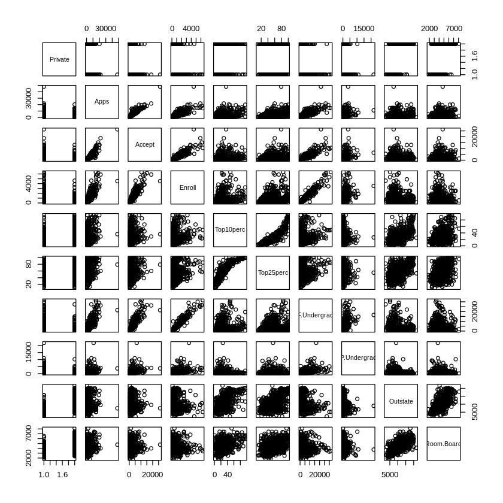

```r
pairs(college[,1:10])
```

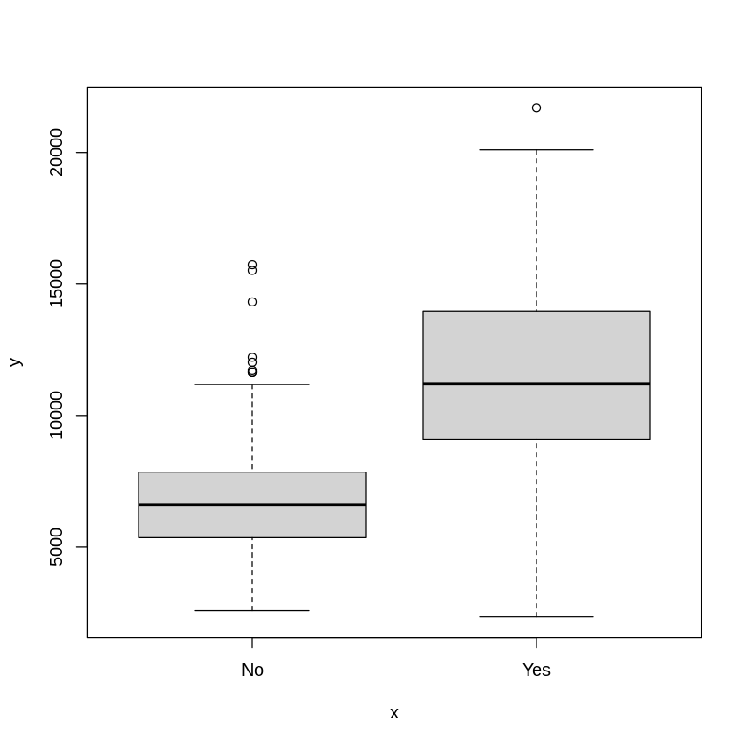

```r
plot(college$Private, college$Outstate)
```

```r
Elite <- rep("No", nrow(college))
Elite[college$Top10perc > 50] <- "Yes"
Elite <- as.factor(Elite)
college <- data.frame(college, Elite)

summary(college$Elite)
```

**No**

699

**Yes**

78

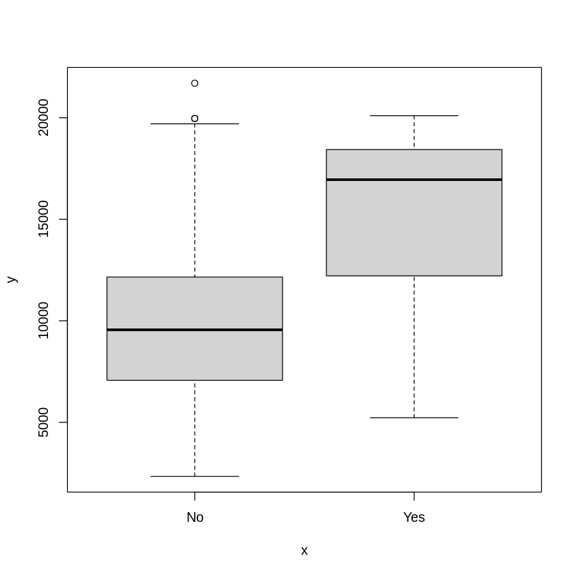

```r
plot(college$Elite, college$Outstate)
```

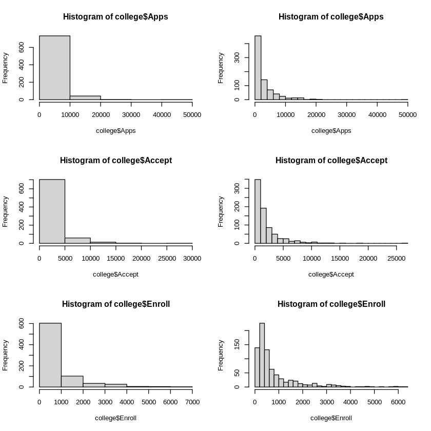

```r
par(mfrow = c(3, 2))
hist(college$Apps, breaks=5)
hist(college$Apps, breaks=25)
hist(college$Accept, breaks=5)
hist(college$Accept, breaks=25)
hist(college$Enroll, breaks=5)
hist(college$Enroll, breaks=25)
```

```r
R_Squared = data.frame("Outstate - " = character(), r_squared = double())
j = 1

for (i in 1:ncol(college)){
    col = colnames(college)[i]
    if (col == "Outstate"){
        next
    }
    lm.fit = lm(college$Outstate ~ college[[i]])
    r_squared = summary(lm.fit) $ r.squared

    R_Squared[j,] = c(col, r_squared)
    j = j+1
}

R_Squared = R_Squared[ order(R_Squared[,2] ), ]
print(R_Squared)
```

```
   Outstate...           r_squared
3       Accept 0.00066329667074234
10       Books 0.00150970078133981
2         Apps 0.00251592866808001
4       Enroll  0.0241732047240198
7  F.Undergrad  0.0465446100334555
8  P.Undergrad  0.0642684953060785
11    Personal  0.0894529731925777
12         PhD   0.146675523192429
18       Elite   0.159581676911116
13    Terminal   0.166450290976491
6    Top25perc   0.239506322870203
1      Private   0.305421909248679
14   S.F.Ratio   0.307826648945538
5    Top10perc   0.316215641478285
15 perc.alumni   0.320653131342875
17   Grad.Rate   0.326372182117834
9   Room.Board   0.428051435299532
16      Expend   0.452631070130932
```

In the above experiment, I would like to find out the best single predictor for Outstate in the College dataset. The data is fit using lm module in R, and the R^2 is extracted and sorted from low to high. According to the R^2 score, Expend is found to have the highest correlation with Outstate while Accept has the lowest correlation. One interesting discovery is that the number of applications, acceptance, and enrollment are among the variables with the least value of R^2.

## Chapter 2: Q10

a

```r
install.packages("ISLR2")
library(ISLR2)
```

```r
Boston
```

A data.frame: 506 × 13

|  | crim <dbl> | zn <dbl> | indus <dbl> | chas <int> | nox <dbl> | rm <dbl> | age <dbl> | dis <dbl> | rad <int> | tax <dbl> | ptratio <dbl> | lstat <dbl> | medv <dbl> |
| --- | --- | --- | --- | --- | --- | --- | --- | --- | --- | --- | --- | --- | --- |
| 1 | 0.00632 | 18.0 | 2.31 | 0 | 0.538 | 6.575 | 65.2 | 4.0900 | 1 | 296 | 15.3 | 4.98 | 24.0 |
| 2 | 0.02731 | 0.0 | 7.07 | 0 | 0.469 | 6.421 | 78.9 | 4.9671 | 2 | 242 | 17.8 | 9.14 | 21.6 |
| 3 | 0.02729 | 0.0 | 7.07 | 0 | 0.469 | 7.185 | 61.1 | 4.9671 | 2 | 242 | 17.8 | 4.03 | 34.7 |
| 4 | 0.03237 | 0.0 | 2.18 | 0 | 0.458 | 6.998 | 45.8 | 6.0622 | 3 | 222 | 18.7 | 2.94 | 33.4 |
| 5 | 0.06905 | 0.0 | 2.18 | 0 | 0.458 | 7.147 | 54.2 | 6.0622 | 3 | 222 | 18.7 | 5.33 | 36.2 |
| 6 | 0.02985 | 0.0 | 2.18 | 0 | 0.458 | 6.430 | 58.7 | 6.0622 | 3 | 222 | 18.7 | 5.21 | 28.7 |
| 7 | 0.08829 | 12.5 | 7.87 | 0 | 0.524 | 6.012 | 66.6 | 5.5605 | 5 | 311 | 15.2 | 12.43 | 22.9 |
| 8 | 0.14455 | 12.5 | 7.87 | 0 | 0.524 | 6.172 | 96.1 | 5.9505 | 5 | 311 | 15.2 | 19.15 | 27.1 |
| 9 | 0.21124 | 12.5 | 7.87 | 0 | 0.524 | 5.631 | 100.0 | 6.0821 | 5 | 311 | 15.2 | 29.93 | 16.5 |
| 10 | 0.17004 | 12.5 | 7.87 | 0 | 0.524 | 6.004 | 85.9 | 6.5921 | 5 | 311 | 15.2 | 17.10 | 18.9 |
| 11 | 0.22489 | 12.5 | 7.87 | 0 | 0.524 | 6.377 | 94.3 | 6.3467 | 5 | 311 | 15.2 | 20.45 | 15.0 |
| 12 | 0.11747 | 12.5 | 7.87 | 0 | 0.524 | 6.009 | 82.9 | 6.2267 | 5 | 311 | 15.2 | 13.27 | 18.9 |
| 13 | 0.09378 | 12.5 | 7.87 | 0 | 0.524 | 5.889 | 39.0 | 5.4509 | 5 | 311 | 15.2 | 15.71 | 21.7 |
| 14 | 0.62976 | 0.0 | 8.14 | 0 | 0.538 | 5.949 | 61.8 | 4.7075 | 4 | 307 | 21.0 | 8.26 | 20.4 |
| 15 | 0.63796 | 0.0 | 8.14 | 0 | 0.538 | 6.096 | 84.5 | 4.4619 | 4 | 307 | 21.0 | 10.26 | 18.2 |
| 16 | 0.62739 | 0.0 | 8.14 | 0 | 0.538 | 5.834 | 56.5 | 4.4986 | 4 | 307 | 21.0 | 8.47 | 19.9 |
| 17 | 1.05393 | 0.0 | 8.14 | 0 | 0.538 | 5.935 | 29.3 | 4.4986 | 4 | 307 | 21.0 | 6.58 | 23.1 |
| 18 | 0.78420 | 0.0 | 8.14 | 0 | 0.538 | 5.990 | 81.7 | 4.2579 | 4 | 307 | 21.0 | 14.67 | 17.5 |
| 19 | 0.80271 | 0.0 | 8.14 | 0 | 0.538 | 5.456 | 36.6 | 3.7965 | 4 | 307 | 21.0 | 11.69 | 20.2 |
| 20 | 0.72580 | 0.0 | 8.14 | 0 | 0.538 | 5.727 | 69.5 | 3.7965 | 4 | 307 | 21.0 | 11.28 | 18.2 |
| 21 | 1.25179 | 0.0 | 8.14 | 0 | 0.538 | 5.570 | 98.1 | 3.7979 | 4 | 307 | 21.0 | 21.02 | 13.6 |
| 22 | 0.85204 | 0.0 | 8.14 | 0 | 0.538 | 5.965 | 89.2 | 4.0123 | 4 | 307 | 21.0 | 13.83 | 19.6 |
| 23 | 1.23247 | 0.0 | 8.14 | 0 | 0.538 | 6.142 | 91.7 | 3.9769 | 4 | 307 | 21.0 | 18.72 | 15.2 |
| 24 | 0.98843 | 0.0 | 8.14 | 0 | 0.538 | 5.813 | 100.0 | 4.0952 | 4 | 307 | 21.0 | 19.88 | 14.5 |
| 25 | 0.75026 | 0.0 | 8.14 | 0 | 0.538 | 5.924 | 94.1 | 4.3996 | 4 | 307 | 21.0 | 16.30 | 15.6 |
| 26 | 0.84054 | 0.0 | 8.14 | 0 | 0.538 | 5.599 | 85.7 | 4.4546 | 4 | 307 | 21.0 | 16.51 | 13.9 |
| 27 | 0.67191 | 0.0 | 8.14 | 0 | 0.538 | 5.813 | 90.3 | 4.6820 | 4 | 307 | 21.0 | 14.81 | 16.6 |
| 28 | 0.95577 | 0.0 | 8.14 | 0 | 0.538 | 6.047 | 88.8 | 4.4534 | 4 | 307 | 21.0 | 17.28 | 14.8 |
| 29 | 0.77299 | 0.0 | 8.14 | 0 | 0.538 | 6.495 | 94.4 | 4.4547 | 4 | 307 | 21.0 | 12.80 | 18.4 |
| 30 | 1.00245 | 0.0 | 8.14 | 0 | 0.538 | 6.674 | 87.3 | 4.2390 | 4 | 307 | 21.0 | 11.98 | 21.0 |
| ⋮ | ⋮ | ⋮ | ⋮ | ⋮ | ⋮ | ⋮ | ⋮ | ⋮ | ⋮ | ⋮ | ⋮ | ⋮ | ⋮ |
| 477 | 4.87141 | 0 | 18.10 | 0 | 0.614 | 6.484 | 93.6 | 2.3053 | 24 | 666 | 20.2 | 18.68 | 16.7 |
| 478 | 15.02340 | 0 | 18.10 | 0 | 0.614 | 5.304 | 97.3 | 2.1007 | 24 | 666 | 20.2 | 24.91 | 12.0 |
| 479 | 10.23300 | 0 | 18.10 | 0 | 0.614 | 6.185 | 96.7 | 2.1705 | 24 | 666 | 20.2 | 18.03 | 14.6 |
| 480 | 14.33370 | 0 | 18.10 | 0 | 0.614 | 6.229 | 88.0 | 1.9512 | 24 | 666 | 20.2 | 13.11 | 21.4 |
| 481 | 5.82401 | 0 | 18.10 | 0 | 0.532 | 6.242 | 64.7 | 3.4242 | 24 | 666 | 20.2 | 10.74 | 23.0 |
| 482 | 5.70818 | 0 | 18.10 | 0 | 0.532 | 6.750 | 74.9 | 3.3317 | 24 | 666 | 20.2 | 7.74 | 23.7 |
| 483 | 5.73116 | 0 | 18.10 | 0 | 0.532 | 7.061 | 77.0 | 3.4106 | 24 | 666 | 20.2 | 7.01 | 25.0 |
| 484 | 2.81838 | 0 | 18.10 | 0 | 0.532 | 5.762 | 40.3 | 4.0983 | 24 | 666 | 20.2 | 10.42 | 21.8 |
| 485 | 2.37857 | 0 | 18.10 | 0 | 0.583 | 5.871 | 41.9 | 3.7240 | 24 | 666 | 20.2 | 13.34 | 20.6 |
| 486 | 3.67367 | 0 | 18.10 | 0 | 0.583 | 6.312 | 51.9 | 3.9917 | 24 | 666 | 20.2 | 10.58 | 21.2 |
| 487 | 5.69175 | 0 | 18.10 | 0 | 0.583 | 6.114 | 79.8 | 3.5459 | 24 | 666 | 20.2 | 14.98 | 19.1 |
| 488 | 4.83567 | 0 | 18.10 | 0 | 0.583 | 5.905 | 53.2 | 3.1523 | 24 | 666 | 20.2 | 11.45 | 20.6 |
| 489 | 0.15086 | 0 | 27.74 | 0 | 0.609 | 5.454 | 92.7 | 1.8209 | 4 | 711 | 20.1 | 18.06 | 15.2 |
| 490 | 0.18337 | 0 | 27.74 | 0 | 0.609 | 5.414 | 98.3 | 1.7554 | 4 | 711 | 20.1 | 23.97 | 7.0 |
| 491 | 0.20746 | 0 | 27.74 | 0 | 0.609 | 5.093 | 98.0 | 1.8226 | 4 | 711 | 20.1 | 29.68 | 8.1 |
| 492 | 0.10574 | 0 | 27.74 | 0 | 0.609 | 5.983 | 98.8 | 1.8681 | 4 | 711 | 20.1 | 18.07 | 13.6 |
| 493 | 0.11132 | 0 | 27.74 | 0 | 0.609 | 5.983 | 83.5 | 2.1099 | 4 | 711 | 20.1 | 13.35 | 20.1 |
| 494 | 0.17331 | 0 | 9.69 | 0 | 0.585 | 5.707 | 54.0 | 2.3817 | 6 | 391 | 19.2 | 12.01 | 21.8 |
| 495 | 0.27957 | 0 | 9.69 | 0 | 0.585 | 5.926 | 42.6 | 2.3817 | 6 | 391 | 19.2 | 13.59 | 24.5 |
| 496 | 0.17899 | 0 | 9.69 | 0 | 0.585 | 5.670 | 28.8 | 2.7986 | 6 | 391 | 19.2 | 17.60 | 23.1 |
| 497 | 0.28960 | 0 | 9.69 | 0 | 0.585 | 5.390 | 72.9 | 2.7986 | 6 | 391 | 19.2 | 21.14 | 19.7 |
| 498 | 0.26838 | 0 | 9.69 | 0 | 0.585 | 5.794 | 70.6 | 2.8927 | 6 | 391 | 19.2 | 14.10 | 18.3 |
| 499 | 0.23912 | 0 | 9.69 | 0 | 0.585 | 6.019 | 65.3 | 2.4091 | 6 | 391 | 19.2 | 12.92 | 21.2 |
| 500 | 0.17783 | 0 | 9.69 | 0 | 0.585 | 5.569 | 73.5 | 2.3999 | 6 | 391 | 19.2 | 15.10 | 17.5 |
| 501 | 0.22438 | 0 | 9.69 | 0 | 0.585 | 6.027 | 79.7 | 2.4982 | 6 | 391 | 19.2 | 14.33 | 16.8 |
| 502 | 0.06263 | 0 | 11.93 | 0 | 0.573 | 6.593 | 69.1 | 2.4786 | 1 | 273 | 21.0 | 9.67 | 22.4 |
| 503 | 0.04527 | 0 | 11.93 | 0 | 0.573 | 6.120 | 76.7 | 2.2875 | 1 | 273 | 21.0 | 9.08 | 20.6 |
| 504 | 0.06076 | 0 | 11.93 | 0 | 0.573 | 6.976 | 91.0 | 2.1675 | 1 | 273 | 21.0 | 5.64 | 23.9 |
| 505 | 0.10959 | 0 | 11.93 | 0 | 0.573 | 6.794 | 89.3 | 2.3889 | 1 | 273 | 21.0 | 6.48 | 22.0 |
| 506 | 0.04741 | 0 | 11.93 | 0 | 0.573 | 6.030 | 80.8 | 2.5050 | 1 | 273 | 21.0 | 7.88 | 11.9 |

```r
# ?Boston
```

506 rows and 13 columns.

The rows represent housing values in 506 suburbs of Boston.

The columns represents:

```
 ‘crim’ per capita crime rate by town.

 ‘zn’ proportion of residential land zoned for lots over 25,000
      sq.ft.

 ‘indus’ proportion of non-retail business acres per town.

 ‘chas’ Charles River dummy variable (= 1 if tract bounds river; 0
      otherwise).

 ‘nox’ nitrogen oxides concentration (parts per 10 million).

 ‘rm’ average number of rooms per dwelling.

 ‘age’ proportion of owner-occupied units built prior to 1940.

 ‘dis’ weighted mean of distances to five Boston employment
      centres.

 ‘rad’ index of accessibility to radial highways.

 ‘tax’ full-value property-tax rate per $10,000.

 ‘ptratio’ pupil-teacher ratio by town.

 ‘lstat’ lower status of the population (percent).

 ‘medv’ median value of owner-occupied homes in $1000s.
```

b

```r
pairs(Boston)
```

c

```r
cor(Boston)
```

d

```r
par(mfrow = c(1, 3))
hist(Boston$crim, breaks=5)
hist(Boston$crim, breaks=20)
hist(Boston$crim, breaks=100)
```

```r
summary(Boston$crim)
```

```r
par(mfrow = c(1, 3))
hist(Boston$tax, breaks=5)
hist(Boston$tax, breaks=20)
hist(Boston$tax, breaks=100)
```

```r
summary(Boston$tax)
```

```r
par(mfrow = c(1, 3))
hist(Boston$ptratio, breaks=5)
hist(Boston$ptratio, breaks=20)
hist(Boston$ptratio, breaks=100)
```

```r
summary(Boston$ptratio)
```

e

```r
table(Boston$chas)
```

35 of the census tracts in this data set bound the Charles river

f

```r
summary(Boston$ptratio)
```

19.05 is the median pupil-teacher ratio among the towns in this data set

g

```r
Boston[Boston$medv == min(Boston$medv), ]
```

399 and 406 have lowest median value of owner- occupied homes of 5

```r
Boston_percentile <- sapply(Boston, function(x) rank(x)/length(x))
Boston_percentile[c(399,406),]
Boston$chas[c(399,406)]
```

Some findings:

- Both 399 and 406 doesn't bound Charles River
- A lot of the other predictors falls into similar percentiles, such as crim, zn, indus, chas, nox, age, dis, rad, tax, ptratio, and medv and only a few fall into different percentile, such as rm and lstat
- A lot of the other predictors are placed in high percentiles:
  - over 0.95: crim, age, lstat (for 399)
  - between 0.95 and 0.75: indus, nox, rad, tax, ptratio, lstat (for 406)
- Only a few fall into the low percentile:
  - below 0.25: rm, dis

h

```r
sum(Boston$rm > 7)
```

64 census tracts average more than seven rooms per dwelling

```r
sum(Boston$rm > 8)
```

13 census tracts average more than eight rooms per dwelling

```r
Boston_rm_8 <- Boston[Boston$rm > 8,]
table(Boston_rm_8$chas)

Boston_percentile_rm_8 <- Boston_percentile[as.numeric(rownames(Boston_rm_8)),]
colMeans(Boston_percentile_rm_8)
```

Some findings:

- 2 out of 13 bound Charles River
- Most of the predictors falls in the 50th percentile, except:
  - above 75th percentile: rm, medv
  - below 25th percentile: ptratio, lstat

## Chapter 3: Q8

a

```r
Auto
```

```r
lm_horsepower <- lm(mpg ~ horsepower, data = Auto)
summary(lm_horsepower)
```

Given the small p-value of <2e-16, it is likely horsepower is associated with mpg. Therefore, there exists a relationship between the predictor and the response

```r
summary(lm_horsepower)$sigma
mean(Auto$mpg)
summary(lm_horsepower)$sigma / mean(Auto$mpg)
```

Given the RSE and mean value, we obtain a percentage error of around 20%. According to the R^2 value which is 0.6059, 60% of the variance in mpg can be explained by horsepower.

With coefficient of -0.157845, the relationship between the predictor and the response is negative. Therefore, the linear model indicates that automobile with high horsepower is likely to have low mpg.

the associated 95 % confidence and prediction intervals:

```r
predict(lm_horsepower, data.frame(horsepower = 98), interval ="confidence")
predict(lm_horsepower, data.frame(horsepower = 98), interval ="prediction")
```

the predicted mpg associated with a horsepower of 98 is 24.46708

b

```r
plot(Auto$horsepower, Auto$mpg)
abline(lm_horsepower)
```

c

```r
par(mfrow=c(2,2))
plot(lm_horsepower)
```

## Chapter 3: Q9

a

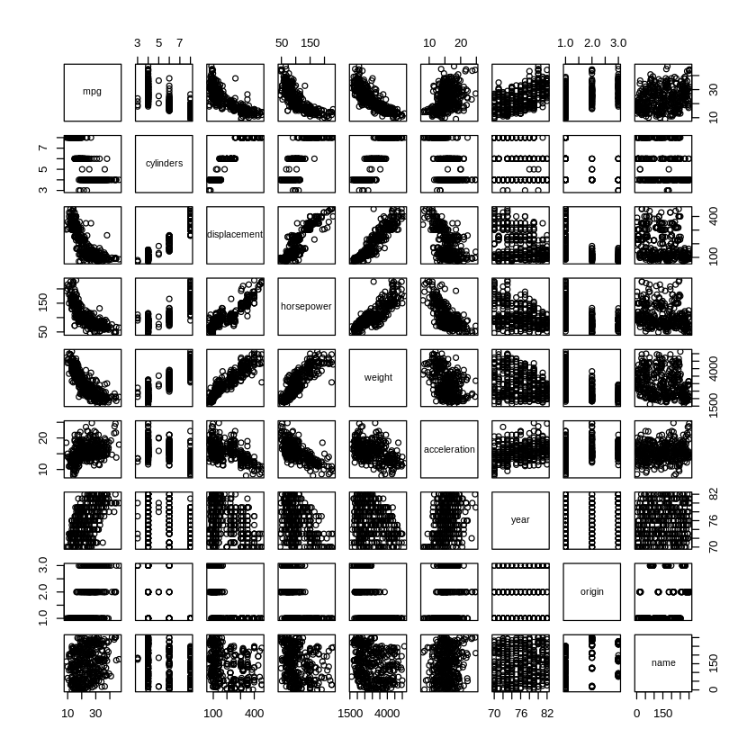

```r
pairs(Auto)
```

b

```r
colnames(Auto)
```

1. 'mpg'

2. 'cylinders'

3. 'displacement'

4. 'horsepower'

5. 'weight'

6. 'acceleration'

7. 'year'

8. 'origin'

9. 'name'

```r
cor(Auto[,-9])
```

A matrix: 8 × 8 of type dbl

|  | mpg | cylinders | displacement | horsepower | weight | acceleration | year | origin |
| --- | --- | --- | --- | --- | --- | --- | --- | --- |
| mpg | 1.0000000 | -0.7776175 | -0.8051269 | -0.7784268 | -0.8322442 | 0.4233285 | 0.5805410 | 0.5652088 |
| cylinders | -0.7776175 | 1.0000000 | 0.9508233 | 0.8429834 | 0.8975273 | -0.5046834 | -0.3456474 | -0.5689316 |
| displacement | -0.8051269 | 0.9508233 | 1.0000000 | 0.8972570 | 0.9329944 | -0.5438005 | -0.3698552 | -0.6145351 |
| horsepower | -0.7784268 | 0.8429834 | 0.8972570 | 1.0000000 | 0.8645377 | -0.6891955 | -0.4163615 | -0.4551715 |
| weight | -0.8322442 | 0.8975273 | 0.9329944 | 0.8645377 | 1.0000000 | -0.4168392 | -0.3091199 | -0.5850054 |
| acceleration | 0.4233285 | -0.5046834 | -0.5438005 | -0.6891955 | -0.4168392 | 1.0000000 | 0.2903161 | 0.2127458 |
| year | 0.5805410 | -0.3456474 | -0.3698552 | -0.4163615 | -0.3091199 | 0.2903161 | 1.0000000 | 0.1815277 |
| origin | 0.5652088 | -0.5689316 | -0.6145351 | -0.4551715 | -0.5850054 | 0.2127458 | 0.1815277 | 1.0000000 |

c

```r
lm_Auto <- lm(mpg ~ .-name, data = Auto)
summary(lm_Auto)
```

```
Call:
lm(formula = mpg ~ . - name, data = Auto)

Residuals:
    Min      1Q  Median      3Q     Max
-9.5903 -2.1565 -0.1169  1.8690 13.0604

Coefficients:
               Estimate Std. Error t value Pr(>|t|)
(Intercept)  -17.218435   4.644294  -3.707  0.00024 ***
cylinders     -0.493376   0.323282  -1.526  0.12780
displacement   0.019896   0.007515   2.647  0.00844 **
horsepower    -0.016951   0.013787  -1.230  0.21963
weight        -0.006474   0.000652  -9.929  < 2e-16 ***
acceleration   0.080576   0.098845   0.815  0.41548
year           0.750773   0.050973  14.729  < 2e-16 ***
origin         1.426141   0.278136   5.127 4.67e-07 ***
---
Signif. codes:  0 ‘***’ 0.001 ‘**’ 0.01 ‘*’ 0.05 ‘.’ 0.1 ‘ ’ 1

Residual standard error: 3.328 on 384 degrees of freedom
Multiple R-squared:  0.8215,	Adjusted R-squared:  0.8182
F-statistic: 252.4 on 7 and 384 DF,  p-value: < 2.2e-16
```

By performing F-test with null hypothesis that all coefficient are zero, i.e. H0: beta_i = 0 for all i, the p-value is given by < 2.2e-16. This indicates that there exists relationship between the predictors and the response and we reject the null hypothesis.

From the p-value of the coefficient of the predictors, we can conclude that all predictors appear to have a statistically significant relationship to the response except cylinders, horsepower, and acceleration.

The coefficient for the year variable suggest that an increasing year variable by 1 while holding the other predictors fixed is associated with an average increase of 0.750773 in the mpg. This means that efficiency of automobiles increase by 0.750773/year.

d

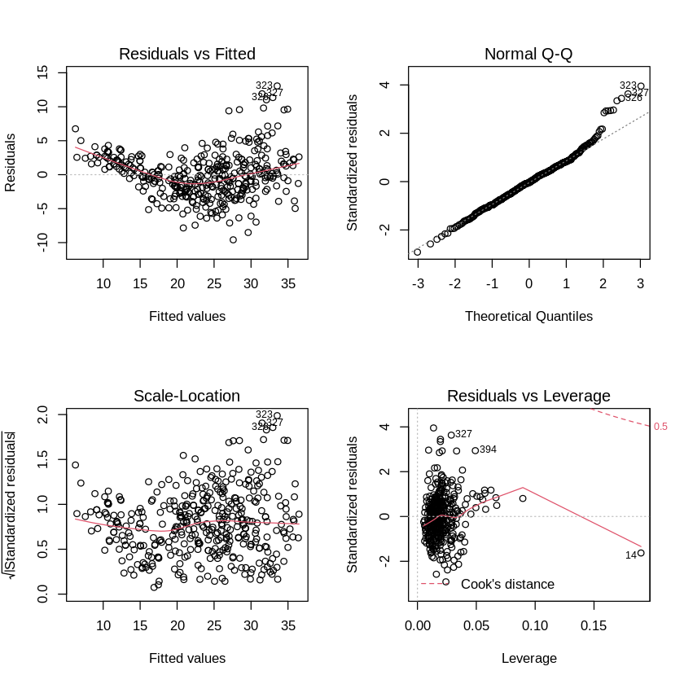

```r
par(mfrow=c(2,2))
plot(lm_Auto)
```

e

```r
lm_Auto_ast <- lm(mpg ~ .*., data = Auto[,-9])
summary(lm_Auto_ast)
```

```
Call:
lm(formula = mpg ~ . * ., data = Auto[, -9])

Residuals:
    Min      1Q  Median      3Q     Max
-7.6303 -1.4481  0.0596  1.2739 11.1386

Coefficients:
                            Estimate Std. Error t value Pr(>|t|)
(Intercept)                3.548e+01  5.314e+01   0.668  0.50475
cylinders                  6.989e+00  8.248e+00   0.847  0.39738
displacement              -4.785e-01  1.894e-01  -2.527  0.01192 *
horsepower                 5.034e-01  3.470e-01   1.451  0.14769
weight                     4.133e-03  1.759e-02   0.235  0.81442
acceleration              -5.859e+00  2.174e+00  -2.696  0.00735 **
year                       6.974e-01  6.097e-01   1.144  0.25340
origin                    -2.090e+01  7.097e+00  -2.944  0.00345 **
cylinders:displacement    -3.383e-03  6.455e-03  -0.524  0.60051
cylinders:horsepower       1.161e-02  2.420e-02   0.480  0.63157
cylinders:weight           3.575e-04  8.955e-04   0.399  0.69000
cylinders:acceleration     2.779e-01  1.664e-01   1.670  0.09584 .
cylinders:year            -1.741e-01  9.714e-02  -1.793  0.07389 .
cylinders:origin           4.022e-01  4.926e-01   0.816  0.41482
displacement:horsepower   -8.491e-05  2.885e-04  -0.294  0.76867
displacement:weight        2.472e-05  1.470e-05   1.682  0.09342 .
displacement:acceleration -3.479e-03  3.342e-03  -1.041  0.29853
displacement:year          5.934e-03  2.391e-03   2.482  0.01352 *
displacement:origin        2.398e-02  1.947e-02   1.232  0.21875
horsepower:weight         -1.968e-05  2.924e-05  -0.673  0.50124
horsepower:acceleration   -7.213e-03  3.719e-03  -1.939  0.05325 .
horsepower:year           -5.838e-03  3.938e-03  -1.482  0.13916
horsepower:origin          2.233e-03  2.930e-02   0.076  0.93931
weight:acceleration        2.346e-04  2.289e-04   1.025  0.30596
weight:year               -2.245e-04  2.127e-04  -1.056  0.29182
weight:origin             -5.789e-04  1.591e-03  -0.364  0.71623
acceleration:year          5.562e-02  2.558e-02   2.174  0.03033 *
acceleration:origin        4.583e-01  1.567e-01   2.926  0.00365 **
year:origin                1.393e-01  7.399e-02   1.882  0.06062 .
---
Signif. codes:  0 ‘***’ 0.001 ‘**’ 0.01 ‘*’ 0.05 ‘.’ 0.1 ‘ ’ 1

Residual standard error: 2.695 on 363 degrees of freedom
Multiple R-squared:  0.8893,	Adjusted R-squared:  0.8808
F-statistic: 104.2 on 28 and 363 DF,  p-value: < 2.2e-16
```

f

```
Call:
lm(formula = mpg ~ ., data = Auto[, -9])

Residuals:
    Min      1Q  Median      3Q     Max
-9.5903 -2.1565 -0.1169  1.8690 13.0604

Coefficients:
               Estimate Std. Error t value Pr(>|t|)
(Intercept)  -17.218435   4.644294  -3.707  0.00024 ***
cylinders     -0.493376   0.323282  -1.526  0.12780
displacement   0.019896   0.007515   2.647  0.00844 **
horsepower    -0.016951   0.013787  -1.230  0.21963
weight        -0.006474   0.000652  -9.929  < 2e-16 ***
acceleration   0.080576   0.098845   0.815  0.41548
year           0.750773   0.050973  14.729  < 2e-16 ***
origin         1.426141   0.278136   5.127 4.67e-07 ***
---
Signif. codes:  0 ‘***’ 0.001 ‘**’ 0.01 ‘*’ 0.05 ‘.’ 0.1 ‘ ’ 1

Residual standard error: 3.328 on 384 degrees of freedom
Multiple R-squared:  0.8215,	Adjusted R-squared:  0.8182
F-statistic: 252.4 on 7 and 384 DF,  p-value: < 2.2e-16
```

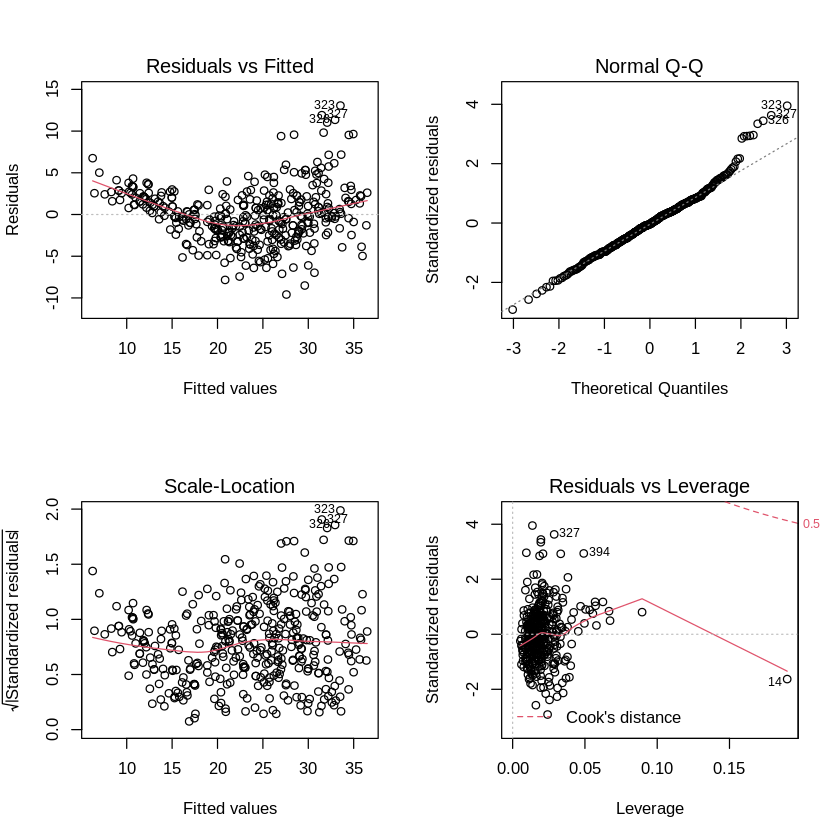

```r
lm_Auto_ast_transform <- lm(mpg ~ ., data = Auto[,-9])
summary(lm_Auto_ast_transform)
par(mfrow=c(2,2))
plot(lm_Auto_ast_transform)
```

```
Call:
lm(formula = mpg ~ . + I(cylinders^2) + I(horsepower^2) + I(acceleration^2),
    data = Auto[, -9])

Residuals:
    Min      1Q  Median      3Q     Max
-9.8488 -1.6976 -0.0639  1.4410 12.1216

Coefficients:
                    Estimate Std. Error t value Pr(>|t|)
(Intercept)       17.2501162  6.4010975   2.695  0.00735 **
cylinders         -2.5830432  1.2080209  -2.138  0.03313 *
displacement      -0.0090379  0.0074258  -1.217  0.22432
horsepower        -0.2975187  0.0344484  -8.637  < 2e-16 ***
weight            -0.0030964  0.0006800  -4.554 7.11e-06 ***
acceleration      -1.4761632  0.5457876  -2.705  0.00714 **
year               0.7355311  0.0453526  16.218  < 2e-16 ***
origin             0.9131603  0.2531125   3.608  0.00035 ***
I(cylinders^2)     0.2534219  0.1003346   2.526  0.01195 *
I(horsepower^2)    0.0008809  0.0001108   7.951 2.13e-14 ***
I(acceleration^2)  0.0351887  0.0159215   2.210  0.02769 *
---
Signif. codes:  0 ‘***’ 0.001 ‘**’ 0.01 ‘*’ 0.05 ‘.’ 0.1 ‘ ’ 1

Residual standard error: 2.957 on 381 degrees of freedom
Multiple R-squared:  0.8601,	Adjusted R-squared:  0.8564
F-statistic: 234.2 on 10 and 381 DF,  p-value: < 2.2e-16
```

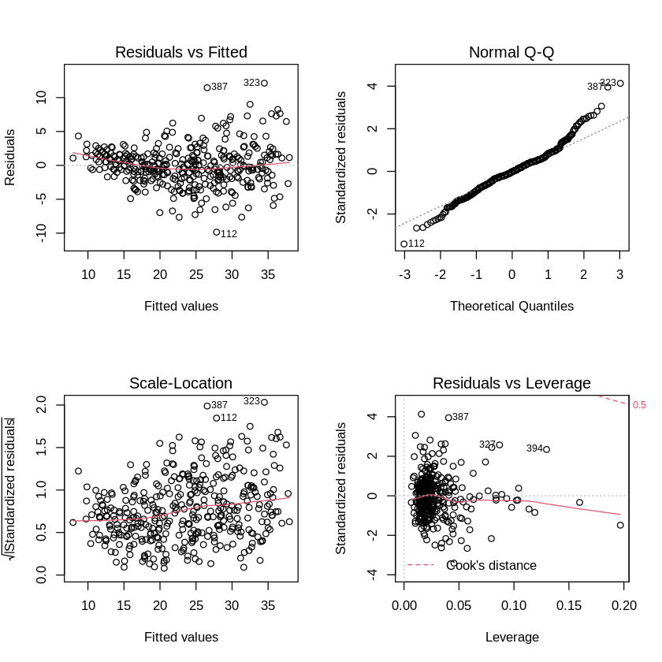

```r
lm_Auto_ast_transform <- lm(mpg ~ .+I(cylinders^2)+I(horsepower^2)+I(acceleration^2), data = Auto[,-9])
summary(lm_Auto_ast_transform)
par(mfrow=c(2,2))
plot(lm_Auto_ast_transform)
```

```
Call:
lm(formula = mpg ~ . + sqrt(cylinders) + sqrt(horsepower) + sqrt(acceleration),
    data = Auto[, -9])

Residuals:
    Min      1Q  Median      3Q     Max
-9.3747 -1.6637 -0.0922  1.5159 12.0592

Coefficients:
                     Estimate Std. Error t value Pr(>|t|)
(Intercept)         7.833e+01  1.858e+01   4.217 3.09e-05 ***
cylinders           2.870e+00  2.343e+00   1.225 0.221392
displacement       -7.473e-03  7.361e-03  -1.015 0.310619
horsepower          3.750e-01  5.102e-02   7.350 1.22e-12 ***
weight             -3.158e-03  6.743e-04  -4.684 3.91e-06 ***
acceleration        1.230e+00  9.832e-01   1.251 0.211720
year                7.413e-01  4.526e-02  16.380  < 2e-16 ***
origin              8.752e-01  2.536e-01   3.451 0.000621 ***
sqrt(cylinders)    -1.314e+01  1.104e+01  -1.191 0.234369
sqrt(horsepower)   -9.565e+00  1.131e+00  -8.453 6.10e-16 ***
sqrt(acceleration) -1.250e+01  7.941e+00  -1.574 0.116281
---
Signif. codes:  0 ‘***’ 0.001 ‘**’ 0.01 ‘*’ 0.05 ‘.’ 0.1 ‘ ’ 1

Residual standard error: 2.952 on 381 degrees of freedom
Multiple R-squared:  0.8606,	Adjusted R-squared:  0.857
F-statistic: 235.2 on 10 and 381 DF,  p-value: < 2.2e-16
```

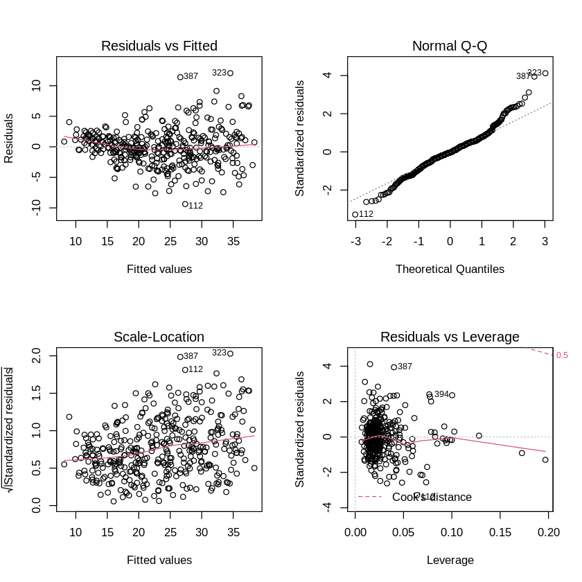

```r
lm_Auto_ast_transform <- lm(mpg ~ .+sqrt(cylinders)+sqrt(horsepower)+sqrt(acceleration), data = Auto[,-9])
summary(lm_Auto_ast_transform)
par(mfrow=c(2,2))
plot(lm_Auto_ast_transform)
```

```
Call:
lm(formula = mpg ~ . + log(cylinders) + log(horsepower) + log(acceleration),
    data = Auto[, -9])

Residuals:
    Min      1Q  Median      3Q     Max
-9.1801 -1.6733 -0.0964  1.5354 12.0891

Coefficients:
                    Estimate Std. Error t value Pr(>|t|)
(Intercept)        1.019e+02  1.484e+01   6.868 2.66e-11 ***
cylinders          8.702e-01  1.205e+00   0.722 0.470607
displacement      -6.439e-03  7.352e-03  -0.876 0.381642
horsepower         1.545e-01  2.632e-02   5.870 9.47e-09 ***
weight            -3.226e-03  6.732e-04  -4.792 2.37e-06 ***
acceleration       3.557e-01  4.791e-01   0.742 0.458285
year               7.438e-01  4.532e-02  16.412  < 2e-16 ***
origin             8.724e-01  2.543e-01   3.431 0.000667 ***
log(cylinders)    -4.894e+00  6.499e+00  -0.753 0.451914
log(horsepower)   -2.487e+01  2.912e+00  -8.542 3.19e-16 ***
log(acceleration) -1.091e+01  7.667e+00  -1.423 0.155637
---
Signif. codes:  0 ‘***’ 0.001 ‘**’ 0.01 ‘*’ 0.05 ‘.’ 0.1 ‘ ’ 1

Residual standard error: 2.956 on 381 degrees of freedom
Multiple R-squared:  0.8602,	Adjusted R-squared:  0.8565
F-statistic: 234.4 on 10 and 381 DF,  p-value: < 2.2e-16
```

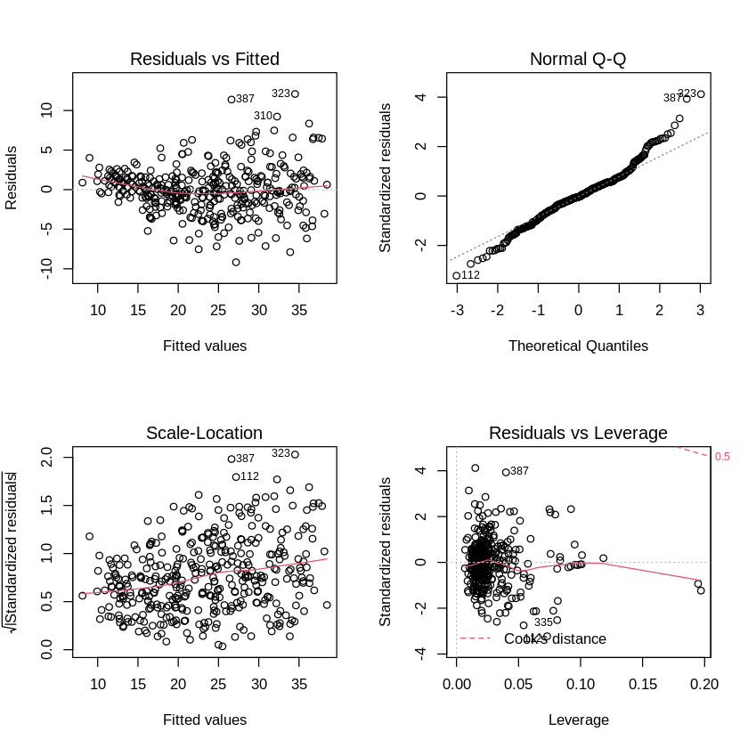

```r
lm_Auto_ast_transform <- lm(mpg ~ .+log(cylinders)+log(horsepower)+log(acceleration), data = Auto[,-9])
summary(lm_Auto_ast_transform)
par(mfrow=c(2,2))
plot(lm_Auto_ast_transform)
```

```
Call:
lm(formula = mpg ~ . + I(cylinders^2) + I(horsepower^2) + I(acceleration^2) +
    sqrt(cylinders) + sqrt(horsepower) + sqrt(acceleration) +
    log(cylinders) + log(horsepower) + log(acceleration), data = Auto[,
    -9])

Residuals:
    Min      1Q  Median      3Q     Max
-7.0704 -1.6670 -0.0796  1.3255 12.1632

Coefficients:
                     Estimate Std. Error t value Pr(>|t|)
(Intercept)        -2.293e+03  8.230e+03  -0.279    0.781
cylinders          -4.590e+02  1.725e+03  -0.266    0.790
displacement       -5.680e-03  7.451e-03  -0.762    0.446
horsepower          3.414e+00  2.862e+00   1.193    0.234
weight             -3.135e-03  6.865e-04  -4.566 6.74e-06 ***
acceleration       -4.682e+01  1.028e+02  -0.456    0.649
year                7.214e-01  4.383e-02  16.458  < 2e-16 ***
origin              9.834e-01  2.463e-01   3.992 7.87e-05 ***
I(cylinders^2)      9.627e+00  2.825e+01   0.341    0.733
I(horsepower^2)    -2.143e-03  2.090e-03  -1.026    0.306
I(acceleration^2)   3.335e-01  5.643e-01   0.591    0.555
sqrt(cylinders)     2.262e+03  1.021e+04   0.222    0.825
sqrt(horsepower)   -9.623e+01  7.937e+01  -1.212    0.226
sqrt(acceleration)  4.160e+02  1.055e+03   0.394    0.694
log(cylinders)     -7.213e+02  4.196e+03  -0.172    0.864
log(horsepower)     1.721e+02  1.524e+02   1.129    0.260
log(acceleration)  -2.608e+02  7.550e+02  -0.345    0.730
---
Signif. codes:  0 ‘***’ 0.001 ‘**’ 0.01 ‘*’ 0.05 ‘.’ 0.1 ‘ ’ 1

Residual standard error: 2.84 on 375 degrees of freedom
Multiple R-squared:  0.873,	Adjusted R-squared:  0.8676
F-statistic: 161.2 on 16 and 375 DF,  p-value: < 2.2e-16
```

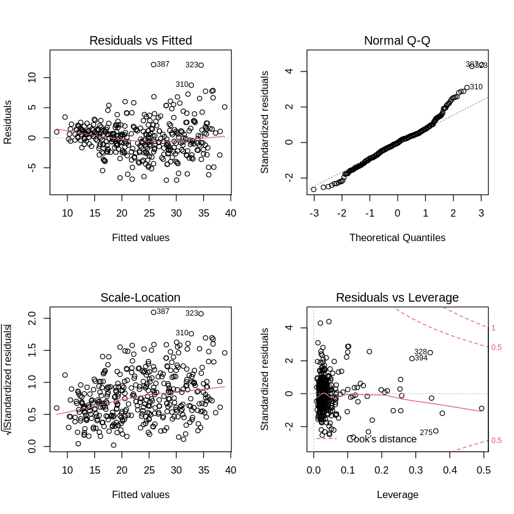

```r
lm_Auto_ast_transform <- lm(mpg ~ .
+I(cylinders^2)+I(horsepower^2)+I(acceleration^2)
+sqrt(cylinders)+sqrt(horsepower)+sqrt(acceleration)
+log(cylinders)+log(horsepower)+log(acceleration)
, data = Auto[,-9])
summary(lm_Auto_ast_transform)
par(mfrow=c(2,2))
plot(lm_Auto_ast_transform)
```

In the above experiment, the R^2 score can be improved from 0.8215 up to 0.873 by adding several transformations of several variables. From the residual plots, we also observe less non-linearity compared to the original linear model without any transformations of variables.

# Coding problem

```r
install.packages("FNN")
```

```r
library(FNN)
library(ggplot2)
rm(list=ls())
set.seed(10)

n <- 200
nt <- n
nrep <- 100
p <- 20
puse <- c(1,2,3,4,10,20)
k <- c(1:9)

sigma <- 0.7

X <- replicate(p,runif(n,-2,2))
Xt <- X
y0 <- sin(2*X[,1])
yt <- sin(2*Xt[,1])

out_knn <- data.frame()
out_lm <- data.frame()

for(i in 1:length(puse)){
  yhat_lm <- matrix(0,nt,nrep)
  yhat_knn <- replicate(length(k),matrix(0,nt,nrep))
  for(l in 1:nrep){
    y <- y0 + rnorm(n,0,sigma)

    ######### DO: fit linear regression using lm funciton, assign predicted value to yhat_lm[,l] #########

    lm.fit = lm(y ~ X[, 1:i])
    yhat_lm[,l] <- predict(lm.fit, data.frame(Xt[, 1:i])) # predicted value by lm


    for(j in 1:length(k)){
      ######### DO: fit knn using knn.reg funciton, assign predicted value to yhat_knn[,l,j] #########

      yhat_knn[,l,j] <- knn.reg(as.data.frame(X[, 1:puse[i]]), as.data.frame(Xt[, 1:puse[i]]), y, k=k[j])$pred # predicted value by knn.reg

    }

    cat(i,"-th p, ",l,"-th repitition finished. \n")
  }

  ######### DO: compute bias and variance of linear regression #########
  # compute mean of predicted values

  ybar_lm <- rowMeans(yhat_lm) # E(f^hat)
  # compute bias^2

  biasSQ_lm <- mean((y0 - ybar_lm) ^ 2) # E[ (f - E(f^hat))^2 ]

  # compute variance

  variance_lm <- mean((yhat_lm - ybar_lm) ^ 2) # E[ (E(f^hat) - f^hat)^2 ]

  # compute total MSE

  err_lm <- biasSQ_lm + variance_lm

  out_lm <- rbind(out_lm,data.frame(error=biasSQ_lm,component="squared-bias",p=paste0("p=",puse[i])))
  out_lm <- rbind(out_lm,data.frame(error=variance_lm,component="variance",p=paste0("p=",puse[i])))
  out_lm <- rbind(out_lm,data.frame(error=err_lm,component="MSE",p=paste0("p=",puse[i])))


  ######### IMPLEMENT: compute bias and variance of knn regression #########
  # compute mean of predicted values

  ybar_knn <- colMeans(aperm(yhat_knn, c(2,1,3))) # E(f^hat)

  # compute bias^2

  biasSQ_knn <- colMeans((y0 - ybar_knn) ^ 2) # E[ (f - E(f^hat))^2 ]

  # compute variance

  variance_knn <- rowMeans(colMeans((aperm(yhat_knn, c(1,3,2)) - replicate(n = nrep, ybar_knn)) ^ 2)) # E[ (E(f^hat) - f^hat)^2 ]

  # compute total MSE

  err_knn <- biasSQ_knn + variance_knn

  out_knn <- rbind(out_knn,data.frame(error=biasSQ_knn,component="squared-bias",K=1/k,p=paste0("p=",puse[i])))
  out_knn<- rbind(out_knn,data.frame(error=variance_knn,component="variance",K=1/k,p=paste0("p=",puse[i])))
  out_knn<- rbind(out_knn,data.frame(error=err_knn,component="MSE",K=1/k,p=paste0("p=",puse[i])))
}
```

[output not shown]

[output cut: 585 more lines]

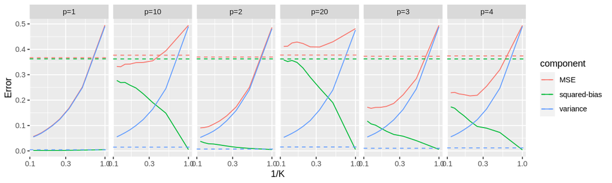

```r
options(repr.plot.width=10, repr.plot.height=3)
p <- ggplot(out_knn,aes(x=K,y=error,col=component)) + geom_line() + scale_x_log10() +
  geom_hline(data=out_lm,aes(yintercept=error,col=component),linetype="dashed") +
  facet_grid(.~p) +
  labs(x="1/K",y="Error")
p
```